# Outreach Data Analysis

```python
import numpy as np
import pandas as pd
import matplotlib.pyplot as plt
import warnings
warnings.filterwarnings('ignore')
```

## 1 Data reading and Exploration

```python
dataset=pd.read_csv('Desktop\outReachData.csv')
dataset.head()
```

|  | NAME | GENDER | AGE | BP(mmHg | RBS(mmol/L) | P(bpm) | CONDITION | MEDICATION |
| --- | --- | --- | --- | --- | --- | --- | --- | --- |
| 0 | Effia Serwaa | Female | 52.0 | 113/71 | NaN | 73.0 | Malaria,body pains | A/L, Ibuprofen |
| 1 | Vincent Mensah | male | 9.0 | NaN | NaN | NaN | Allergic reaction, headache,stomach infection | Cetirizine suspension, Paracetamol, Flagyl |
| 2 | Emelia Annan | Female | 48.0 | 111/74 | NaN | 74.0 | Stomach infection, infection, malaria | Flagyl, Amoxicillin, A/L |
| 3 | Evelyn Acheampong | Female | 10.0 | NaN | NaN | NaN | NaN |  |
| 4 | Sarah Amoasi | Female | 17.0 | 111/67 | NaN | 84.0 | NaN | Folic acid, Cefuroxime |

```python
dataset.info()
```

```
<class 'pandas.core.frame.DataFrame'>
RangeIndex: 135 entries, 0 to 134
Data columns (total 8 columns):
 #   Column       Non-Null Count  Dtype
---  ------       --------------  -----
 0   NAME         135 non-null    object
 1   GENDER       135 non-null    object
 2   AGE          125 non-null    float64
 3   BP(mmHg      96 non-null     object
 4   RBS(mmol/L)  77 non-null     float64
 5   P(bpm)       94 non-null     float64
 6   CONDITION    115 non-null    object
 7   MEDICATION   132 non-null    object
dtypes: float64(3), object(5)
memory usage: 8.6+ KB
```

```python
dataset.describe()
```

|  | AGE | RBS(mmol/L) | P(bpm) |
| --- | --- | --- | --- |
| count | 125.000000 | 77.000000 | 94.000000 |
| mean | 32.568000 | 7.918182 | 83.287234 |
| std | 22.184467 | 11.516450 | 15.230574 |
| min | 2.000000 | 3.800000 | 48.000000 |
| 25% | 13.000000 | 5.100000 | 71.500000 |
| 50% | 31.000000 | 5.800000 | 83.000000 |
| 75% | 48.000000 | 6.800000 | 93.750000 |
| max | 102.000000 | 84.000000 | 121.000000 |

```python
# Calculating the percentages of each gender
gender_counts = dataset['GENDER'].value_counts()
total_count = gender_counts.sum()
gender_percentages = gender_counts / total_count * 100

print(gender_counts)
print(gender_percentages)
```

```
Female    85
male      50
Name: GENDER, dtype: int64
Female    62.962963
male      37.037037
Name: GENDER, dtype: float64
```

## 2 Data Cleaning

Let us explore the RBS(random blood sugar level) column

```python
dataset['RBS(mmol/L)'].unique()
```

```
array([ nan,  5.2,  6.7,  6.2,  5.6,  8.3,  6. ,  6.3,  5.9,  5.5,  6.5,
        5.1,  6.6,  4.5,  5. ,  3.8,  4.3,  5.4,  9.3, 11.7,  7.2,  7.9,
        5.7,  7.3,  6.8,  4.7,  8.2,  5.8,  4. ,  6.1,  8. ,  9. ,  7. ,
        4.1, 11.2,  7.5,  4.4,  3.9,  4.8,  4.9, 84. , 70. ,  9.4,  8.8])
```

We could see that apart from the missing values, the data in here makes sense except the 84 and 70 values which are probably due to typing errors and must be changed to 8.4 and 7.0.

```python
#Replacing the irrational values

dataset['RBS(mmol/L)'] = dataset['RBS(mmol/L)'].replace({84: 8.4, 70: 7.0})
dataset['RBS(mmol/L)'].unique()
```

```
array([ nan,  5.2,  6.7,  6.2,  5.6,  8.3,  6. ,  6.3,  5.9,  5.5,  6.5,
        5.1,  6.6,  4.5,  5. ,  3.8,  4.3,  5.4,  9.3, 11.7,  7.2,  7.9,
        5.7,  7.3,  6.8,  4.7,  8.2,  5.8,  4. ,  6.1,  8. ,  9. ,  7. ,
        4.1, 11.2,  7.5,  4.4,  3.9,  4.8,  4.9,  8.4,  9.4,  8.8])
```

Let's do same to the Heart Rate (blood per method)

```python
dataset['P(bpm)'].unique()
```

```
array([ 73.,  nan,  74.,  84.,  80.,  90.,  57.,  82.,  70., 114.,  62.,
        87.,  79.,  95., 102.,  86.,  94.,  97.,  91., 117.,  83.,  65.,
        75.,  60.,  88.,  99.,  93.,  66.,  76.,  64.,  68., 103.,  71.,
       107., 100.,  48., 121.,  78.,  92.,  63., 106., 112.,  59., 104.,
        69., 101.])
```

The data here also seem valid apart from the issues of missing values

```python
#Splitting the Blood Pressure Column into Systolic and Diastolic Pressures

dataset[['Systolic BP', 'Diastolic BP']] = dataset['BP(mmHg'].str.split('/', expand=True)
df=dataset.drop(['BP(mmHg','NAME'], axis=1)
#to maintain confidentiality the name axis must be dropped.

#Calculating average pressures and average sugar levels
average_systolic_pressure = df['Systolic BP'].astype(float).mean()
average_diastolic_pressure = df['Diastolic BP'].astype(float).mean()
average_RBS = df['RBS(mmol/L)'].astype(float).mean()

print("Average Systolic Pressure:", average_systolic_pressure)
print("Average Diastolic Pressure:", average_diastolic_pressure)
print("Average RBS:", average_RBS)
```

```
Average Systolic Pressure: 124.96875
Average Diastolic Pressure: 74.66666666666667
Average RBS: 6.118181818181818
```

The condition and medication columns seems to have clustered and unorganized data in them therefore they must individually be broken into multiple columns with each column having one condition or medication

```python
max_conditions = df['CONDITION'].str.count(',') + 1
condition_columns = [f'Condition{i+1}' for i in range(int(max_conditions.max()))]
df[condition_columns] = df['CONDITION'].str.split(',', expand=True)


max_medications = df['MEDICATION'].str.count(',') + 1
medication_columns = [f'Medication{i+1}' for i in range(int(max_medications.max()))]
df[medication_columns] = df['MEDICATION'].str.split(',', expand=True)
```

```python
df=df.drop(['CONDITION','MEDICATION'], axis=1)
df.head()
```

|  | GENDER | AGE | RBS(mmol/L) | P(bpm) | Systolic BP | Diastolic BP | Condition1 | Condition2 | Condition3 | Condition4 | Condition5 | Condition6 | Condition7 | Medication1 | Medication2 | Medication3 | Medication4 | Medication5 | Medication6 | Medication7 |
| --- | --- | --- | --- | --- | --- | --- | --- | --- | --- | --- | --- | --- | --- | --- | --- | --- | --- | --- | --- | --- |
| 0 | Female | 52.0 | NaN | 73.0 | 113 | 71 | Malaria | body pains | None | None | None | None | None | A/L | Ibuprofen | None | None | None | None | None |
| 1 | male | 9.0 | NaN | NaN | NaN | NaN | Allergic reaction | headache | stomach infection | None | None | None | None | Cetirizine suspension | Paracetamol | Flagyl | None | None | None | None |
| 2 | Female | 48.0 | NaN | 74.0 | 111 | 74 | Stomach infection | infection | malaria | None | None | None | None | Flagyl | Amoxicillin | A/L | None | None | None | None |
| 3 | Female | 10.0 | NaN | NaN | NaN | NaN | NaN | NaN | NaN | NaN | NaN | NaN | NaN |  | None | None | None | None | None | None |
| 4 | Female | 17.0 | NaN | 84.0 | 111 | 67 | NaN | NaN | NaN | NaN | NaN | NaN | NaN | Folic acid | Cefuroxime | None | None | None | None | None |

```python
#Calculating condtion per particpants

conditions = ['Condition1', 'Condition2', 'Condition3', 'Condition4', 'Condition5', 'Condition6', 'Condition7']
conditions_pp = df[conditions].count().sum()/135

#Calculating Medications per particpants
medications = ['Medication1', 'Medication2', 'Medication3', 'Medication4', 'Medication5', 'Medication6', 'Medication7']
medications_pp = df[medications].count().sum()/135

print("Condtion per particpants :", conditions_pp )
print("Medications per particpants :", medications_pp)
```

```
Condtion per particpants : 2.562962962962963
Medications per particpants : 3.511111111111111
```

### Missing Values Analaysis

```python
df.isnull().sum()
```

```
GENDER            0
AGE              10
RBS(mmol/L)      58
P(bpm)           41
Systolic BP      39
Diastolic BP     39
Condition1       20
Condition2       30
Condition3       65
Condition4      107
Condition5      119
Condition6      128
Condition7      130
Medication1       3
Medication2       6
Medication3      20
Medication4      74
Medication5     110
Medication6     124
Medication7     134
dtype: int64
```

Participants with missing values for RBS and Blood rate are liekly to be children whose blood sugar level and blood rate were not taken, its absence does not necessarily affect this analysis. Null values for Conditions and Medication columns are due to the fact that not all patients have up to 7 conditions or medications. To avoid misrepresentation of data, category for data with missing age will be created so that it is olso analysed

```python
#Categorising the age variable and grouping the data according ages

age_bins = [0, 10, 18, 40, 60, np.inf]
age_labels = ['0-10','11-18', '19-40', '41-60', '60+']

df['Age_Category'] = pd.cut(df['AGE'], bins=age_bins, labels=age_labels, right=False)

df['Age_Category'] = df['Age_Category'].cat.add_categories(['Unknown'])

df['Age_Category'].fillna('Unknown', inplace=True)

data= df.set_index('Age_Category').sort_values('Age_Category', ascending = True)
data
```

| Age_Category | GENDER | AGE | RBS(mmol/L) | P(bpm) | Systolic BP | Diastolic BP | Condition1 | Condition2 | Condition3 | Condition4 | Condition5 | Condition6 | Condition7 | Medication1 | Medication2 | Medication3 | Medication4 | Medication5 | Medication6 | Medication7 |
| --- | --- | --- | --- | --- | --- | --- | --- | --- | --- | --- | --- | --- | --- | --- | --- | --- | --- | --- | --- | --- |
| 0-10 | Female | 5.0 | NaN | NaN | NaN | NaN | headache | ear pain | None | None | None | None | None | flagyl | ear drop | paracetamol | None | None | None | None |
| 0-10 | Female | 2.0 | NaN | NaN | NaN | NaN | fever | cough | None | None | None | None | None | paracetamol suspension | albendazole suspension | cefuroxime suspension | None | None | None | None |
| 0-10 | Female | 4.0 | NaN | NaN | NaN | NaN | fever | diarrhoea | None | None | None | None | None | cefuroxime suspension | flagyl suspension | zinc tablet | paracetamol suspension | None | None | None |
| 0-10 | Female | 9.0 | NaN | NaN | NaN | NaN | vomiting | cough | fever | None | None | None | None | A/L suspension | Paracetamol suspension | Cefuroxime suspension | None | None | None | None |
| 0-10 | Female | 5.0 | NaN | NaN | NaN | NaN | abdominal pains | sore on the leg | fever | None | None | None | None | A/L suspension | Paracetamole suspension | Cefuroxime suspension | None | None | None | None |
| ... | ... | ... | ... | ... | ... | ... | ... | ... | ... | ... | ... | ... | ... | ... | ... | ... | ... | ... | ... | ... |
| Unknown | Female | NaN | 4.5 | 99.0 | 107 | 72 | Burning sensation in the eyes | diziness | fever | cough | runny nose | None | None | A/L | paracetamol | amoxicillin | heamatinic | cool eyes | None | None |
| Unknown | Female | NaN | 5.1 | 91.0 | 225 | 112 | Blurred vision | itchy eyes | cataract | knee pains | waist pains | None | None | epicrom | nifedipine | ibuprofen | diclo gel | None | None | None |
| Unknown | Female | NaN | 5.6 | 83.0 | 138 | 80 | itchy eye | burning sensation in eye | tearing | numbness | fever | cough | None | Epicrom | cool eyes | amoxicillin | flagyl | vitamin C | paracetamol | None |
| Unknown | Female | NaN | NaN | NaN | NaN | NaN | NaN | NaN | NaN | NaN | NaN | NaN | NaN | cool eyes | None | None | None | None | None | None |
| Unknown | male | NaN | NaN | NaN | NaN | NaN | NaN | NaN | NaN | NaN | NaN | NaN | NaN | cefuroxime | A/L | ibuprofen | vitamin C | None | None | None |

135 rows × 20 columns

## 3 Data Visualisation

#### Visualizing age by gender

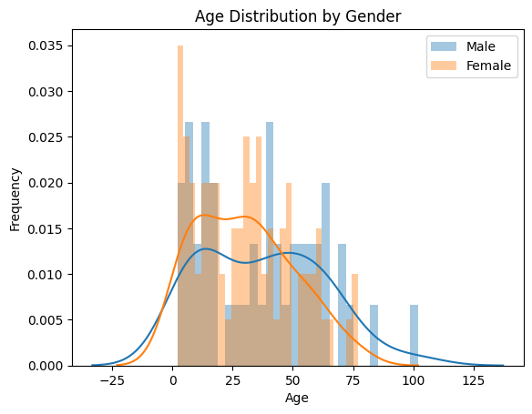

```python
# Filtering the data by gender
male_data = data[data['GENDER'] == 'male']
female_data = data[data['GENDER'] == 'Female']

# Plotting the age distribution for males and females
sns.distplot(male_data['AGE'], bins=30,  label='Male')
sns.distplot(female_data['AGE'], bins=30,  label='Female')

plt.xlabel('Age')
plt.ylabel('Frequency')
plt.title('Age Distribution by Gender')

plt.legend()

# saving the graph
plt.savefig('C:/Users/Daniel Appiah/Desktop/age_distribution.png')
plt.show()
```

Statistical description

```python
# Describing the age distribution for males
male_age_stats = male_data['AGE'].describe()
print("Male Age Statistics:")
print(male_age_stats)

# Describing the age distribution for females
female_age_stats = female_data['AGE'].describe()
print("Female Age Statistics:")
print(female_age_stats)

# printing the number of people in thenage categories
print(data.index.value_counts())
```

```
Male Age Statistics:
count     45.000000
mean      37.244444
std       25.164148
min        2.000000
25%       13.000000
50%       40.000000
75%       58.000000
max      102.000000
Name: AGE, dtype: float64
Female Age Statistics:
count    80.000000
mean     29.937500
std      20.008444
min       2.000000
25%      12.750000
50%      30.000000
75%      45.000000
max      77.000000
Name: AGE, dtype: float64
19-40      34
41-60      30
0-10       24
11-18      19
60+        18
Unknown    10
Name: Age_Category, dtype: int64
```

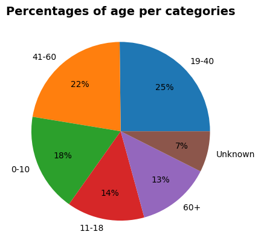

```python
# A pie chart of the age distribution.
age =pd.DataFrame(data.index.value_counts())

plt.pie(age['Age_Category'],labels=age.index ,autopct='%1.0f%%',pctdistance=0.7)
plt.title('Percentages of age per categories', fontdict={'fontweight': 'bold', 'fontsize': 14})
plt.savefig('C:/Users/Daniel Appiah/Desktop/age_pie.png')

plt.show()
```

### Heart Pressure

```python
# Statistical features of the blood pressures
data['Systolic BP']= data['Systolic BP'].astype(float)
data[ 'Diastolic BP']= data[ 'Diastolic BP'].astype(float)

data[[ 'Diastolic BP','Systolic BP']].describe()
```

|  | Diastolic BP | Systolic BP |
| --- | --- | --- |
| count | 96.000000 | 96.000000 |
| mean | 74.666667 | 124.968750 |
| std | 17.133941 | 27.181051 |
| min | 40.000000 | 76.000000 |
| 25% | 64.000000 | 107.750000 |
| 50% | 71.500000 | 118.000000 |
| 75% | 80.000000 | 136.500000 |
| max | 163.000000 | 225.000000 |

```python
# categorising and visualising the Heart Pressure

#Diastolic Pressure
DBP_bins = [30,  60, 75, 85,100, np.inf]
DBP_labels = ['30-60','61-75', '76-85', '86-100', '100+']

data['DBP_Category'] = pd.cut(data['Diastolic BP'], bins=DBP_bins, labels=DBP_labels, right=False)


DBP= data['DBP_Category'].dropna()

DBP= data.set_index('DBP_Category')['Diastolic BP']
DBP=pd.DataFrame(DBP.index.value_counts())
print(DBP)

#Systoltic Pressure
SBP_bins = [70,  90, 115,125 ,140, np.inf]
SBP_labels = ['70-90','91-115', '116-125', '126-140', '140+']

data['SBP_Category'] = pd.cut(data['Systolic BP'], bins=SBP_bins, labels=SBP_labels, right=False)

SBP= data['SBP_Category'].dropna()

SBP= data.set_index('SBP_Category')['Systolic BP']
SBP= pd.DataFrame(SBP.index.value_counts())
SBP
```

```
        DBP_Category
61-75             49
76-85             18
30-60             10
86-100            10
100+               9
```

|  | SBP_Category |
| --- | --- |
| 91-115 | 38 |
| 126-140 | 20 |
| 140+ | 19 |
| 116-125 | 15 |
| 70-90 | 4 |

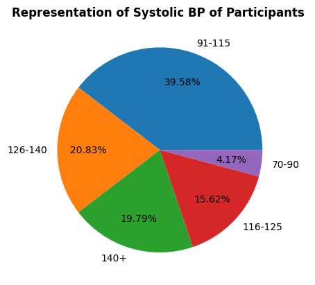

```python
#pie of the systolic BP

plt.pie(SBP['SBP_Category'],labels=SBP.index ,autopct='%1.2f%%',pctdistance=0.7)
plt.title('Representation of Systolic BP of Participants ', fontdict={'fontweight': 'bold'})
plt.savefig('C:/Users/Daniel Appiah/Desktop/SBP_pie.png')

plt.show()
```

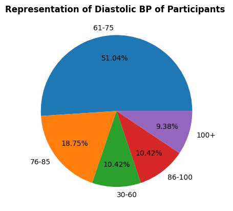

```python
#pie of the diastolic BP

plt.pie(DBP['DBP_Category'],labels=DBP.index ,autopct='%1.2f%%',pctdistance=0.7)
plt.title('Representation of Diastolic BP of Participants ', fontdict={'fontweight': 'bold'})
plt.savefig('C:/Users/Daniel Appiah/Desktop/DBP_pie.png')

plt.show()
```

### Analysis of the Children data

```python
children = data.loc['0-10']
children.describe()
```

|  | AGE | RBS(mmol/L) | P(bpm) | Systolic BP | Diastolic BP |
| --- | --- | --- | --- | --- | --- |
| count | 24.000000 | 0.0 | 0.0 | 0.0 | 0.0 |
| mean | 5.083333 | NaN | NaN | NaN | NaN |
| std | 2.224697 | NaN | NaN | NaN | NaN |
| min | 2.000000 | NaN | NaN | NaN | NaN |
| 25% | 3.750000 | NaN | NaN | NaN | NaN |
| 50% | 5.000000 | NaN | NaN | NaN | NaN |
| 75% | 7.000000 | NaN | NaN | NaN | NaN |
| max | 9.000000 | NaN | NaN | NaN | NaN |

```python
children['GENDER'].value_counts()
```

```
Female    16
male       8
Name: GENDER, dtype: int64
```

We could see that the total number of children that came were 24, with mean age of 5 years with 16 females and 8 males. Let's take a look at the disease conditions and medications.

```python
#converting each column with disease conditions into separate dataframe

a=pd.DataFrame(children.loc[:,['Condition1']].value_counts()).sort_values('Condition1')

b=pd.DataFrame(children.loc[:,['Condition2']].value_counts()).sort_values('Condition2')
b= b.rename_axis('Condition1')
c=pd.DataFrame(children.loc[:,['Condition3']].value_counts()).sort_values('Condition3')
c=c.rename_axis('Condition1')

d=pd.DataFrame(children.loc[:,['Condition4']].value_counts()).sort_values('Condition4')
d=d.rename_axis('Condition1')

e=pd.DataFrame(children.loc[:,['Condition5']].value_counts()).sort_values('Condition5')
e=e.rename_axis('Condition1')

f=pd.DataFrame(children.loc[:,['Condition6']].value_counts()).sort_values('Condition6')
f=f.rename_axis('Condition1')

g=pd.DataFrame(children.loc[:,['Condition7']].value_counts()).sort_values('Condition7')
g=g.rename_axis('Condition1')
```

```python
#concatenating the dataframes
merged_df = pd.concat([a, b, c,d,e,f,g])
merged_df= merged_df.rename(columns={0: 'frequency'})

merged_df= merged_df.rename({'abdominal pain': 'abdominal pains'})

merged_df = merged_df.reset_index()


merged_df['Condition1'] = merged_df['Condition1'].str.strip().str.lower()


merged_df = merged_df.groupby('Condition1')['frequency'].sum()

merged_df = pd.DataFrame(merged_df)
merged_df = merged_df.sort_values('frequency', ascending= False)
```

```python
table1 = merged_df.rename_axis('Condition')
table1.to_csv('C:/Users/Daniel Appiah/Desktop/children_ condition.csv')

table1
```

| Condition | frequency |
| --- | --- |
| fever | 16 |
| cough | 10 |
| abdominal pains | 7 |
| headache | 4 |
| rashes | 3 |
| allergic reaction | 1 |
| diarrhoea | 1 |
| ear pain | 1 |
| itchy body | 1 |
| loss of appetite | 1 |
| runny nose | 1 |
| sore on the leg | 1 |
| stomach infection | 1 |
| vomiting | 1 |

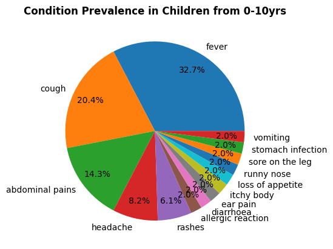

```python
#plotting a pie chart for the data

percentages = merged_df['frequency'] / merged_df['frequency'].sum() * 100

plt.pie(percentages, labels=merged_df.index, autopct='%1.1f%%',pctdistance=0.8)
plt.title('Condition Prevalence in Children from 0-10yrs', fontdict={'fontweight': 'bold'})
plt.savefig('C:/Users/Daniel Appiah/Desktop/Children_conditions_pie.png')

plt.show()
```

### Children Medications

```python
# Slicing columns with medications into separate dfs
a_1=pd.DataFrame(children.loc[:,['Medication1']].value_counts()).sort_values('Medication1')

b_1=pd.DataFrame(children.loc[:,['Medication2']].value_counts()).sort_values('Medication2')
b_1= b_1.rename_axis('Medication1')
c_1=pd.DataFrame(children.loc[:,['Medication3']].value_counts()).sort_values('Medication3')
c_1=c_1.rename_axis('Medication1')

d_1=pd.DataFrame(children.loc[:,['Medication4']].value_counts()).sort_values('Medication4')
d_1=d_1.rename_axis('Medication1')

e_1=pd.DataFrame(children.loc[:,['Medication5']].value_counts()).sort_values('Medication5')
e_1=e_1.rename_axis('Medication1')

f_1=pd.DataFrame(children.loc[:,['Medication6']].value_counts()).sort_values('Medication6')
f_1=f_1.rename_axis('Medication1')

g_1=pd.DataFrame(children.loc[:,['Medication7']].value_counts()).sort_values('Medication7')
g_1=g_1.rename_axis('Medication1')
```

```python
#concatenating the dfs
merged = pd.concat([a_1, b_1, c_1,d_1,e_1,f_1,g_1])
merged= merged.rename(columns={0: 'frequency'})

merged= merged.rename({'A/L': 'A/L suspension'})
merged= merged.rename({' albendazole': 'albendazole suspension'})
merged= merged.rename({' amoxicillin': 'amoxicillin suspension'})
merged= merged.rename({' Cefuroxime': 'cefuroxime suspension'})
merged= merged.rename({' cetirizine': 'cetirizine suspension'})
merged= merged.rename({' Paracetamole suspension': 'paracetamol suspension'})


merged = merged.reset_index()


merged['Medication1'] = merged['Medication1'].str.strip().str.lower()


merged = merged.groupby('Medication1')['frequency'].sum()

merged = pd.DataFrame(merged)
merged= merged.sort_values('frequency', ascending= False)
```

```python
table6 = merged.rename_axis('Medications')
table6.to_csv('C:/Users/Daniel Appiah/Desktop/children_med_table.csv')

table6
```

| Medications | frequency |
| --- | --- |
| paracetamol | 12 |
| paracetamol suspension | 12 |
| cetirizine suspension | 11 |
| a/l suspension | 9 |
| cefuroxime suspension | 6 |
| flagyl | 6 |
| vitamin c | 4 |
| albendazole suspension | 3 |
| amoxicillin suspension | 3 |
| flagyl suspension | 3 |
| zinc tablet | 2 |
| azithromycin | 1 |
| ear drop | 1 |
| nizoral shampoo | 1 |

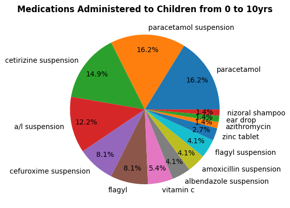

```python
#plotting a pie chart for the data

percentages = merged['frequency'] / merged['frequency'].sum() * 100

plt.pie(percentages, labels=merged.index, autopct='%1.1f%%', pctdistance= 0.8)
plt.title('Medications Administered to Children from 0 to 10yrs', fontdict= {'fontweight':'bold'})
plt.savefig('C:/Users/Daniel Appiah/Desktop/Children_conditions_pie.png')
plt.savefig('C:/Users/Daniel Appiah/Desktop/Children_medications_pie.png')

plt.show()
```

The use of tablets instead of suspension must be checked

### Adolescent Medical Condition

```python
adolescent = data.loc['11-18']
adolescent.describe()
```

|  | AGE | RBS(mmol/L) | P(bpm) | Systolic BP | Diastolic BP |
| --- | --- | --- | --- | --- | --- |
| count | 19.000000 | 6.000000 | 12.000000 | 12.000000 | 12.000000 |
| mean | 14.052632 | 5.100000 | 92.166667 | 98.500000 | 63.000000 |
| std | 2.222953 | 0.565685 | 19.636855 | 11.500988 | 10.557203 |
| min | 10.000000 | 4.400000 | 48.000000 | 81.000000 | 40.000000 |
| 25% | 12.500000 | 4.725000 | 83.000000 | 89.500000 | 58.000000 |
| 50% | 14.000000 | 5.000000 | 93.000000 | 97.000000 | 65.500000 |
| 75% | 16.000000 | 5.575000 | 100.750000 | 107.250000 | 70.250000 |
| max | 17.000000 | 5.800000 | 121.000000 | 117.000000 | 76.000000 |

```python
adolescent['GENDER'].value_counts()
```

```
Female    12
male       7
Name: GENDER, dtype: int64
```

They are a total of 19 with mean age of 14 years with 12 females and 7 males.

```python
#forming separate dfs from condition columns
a2=pd.DataFrame(adolescent.loc[:,['Condition1']].value_counts()).sort_values('Condition1')
a2= a2.rename_axis('Condition')
b2=pd.DataFrame(adolescent.loc[:,['Condition2']].value_counts()).sort_values('Condition2')
b2= b2.rename_axis('Condition')
c2=pd.DataFrame(adolescent.loc[:,['Condition3']].value_counts()).sort_values('Condition3')
c2=c2.rename_axis('Condition')

d2=pd.DataFrame(adolescent.loc[:,['Condition4']].value_counts()).sort_values('Condition4')
d2=d2.rename_axis('Condition')

e2=pd.DataFrame(adolescent.loc[:,['Condition5']].value_counts()).sort_values('Condition5')
e2=e2.rename_axis('Condition')

f2=pd.DataFrame(adolescent.loc[:,['Condition6']].value_counts()).sort_values('Condition6')
f2=f2.rename_axis('Condition')

g2=pd.DataFrame(adolescent.loc[:,['Condition7']].value_counts()).sort_values('Condition7')
g2=g2.rename_axis('Condition')
```

```python
#merging the slices
merge = pd.concat([a2, b2, c2,d2,e2,f2,g2])
merge= merge.rename(columns={0: 'frequency'})

merge= merge.rename({'abdominal pain': 'abdominal pains'})
merge= merge.rename({'burning sensation in the eye': 'burning eye'})
merge= merge.rename({' burning sensation': 'burning eye'})
merge= merge.rename({' burning sensation in eyes': 'burning eye'})
merge= merge.rename({' eye discharge': 'tearing'})
merge= merge.rename({' hearburns': 'heartburns'})
merge= merge.rename({' itchy eye': 'itchy eyes'})
merge= merge.rename({'Itchy eye': 'itchy eyes'})
merge= merge.rename({'itchy eye': 'itchy eyes'})

merge = merge.reset_index()

merge['Condition'] = merge['Condition'].str.strip().str.lower()

merge = merge.groupby('Condition')['frequency'].sum()

merge = pd.DataFrame(merge)
merge= merge.sort_values('frequency', ascending= False)

merge.index
```

```
Index(['abdominal pains', 'cough', 'headache', 'itchy eyes', 'tearing',
       'burning eye', 'body pains', 'chills', 'fever', 'heartburns',
       'itchy body', 'lipima', 'photophobic', 'poor vision', 'pregnant woman',
       'syphilis'],
      dtype='object', name='Condition')
```

```python
table2 = merge.rename_axis('Condition')
table2.to_csv('C:/Users/Daniel Appiah/Desktop/adolescent_ c_table.csv')

table2
```

| Condition | frequency |
| --- | --- |
| abdominal pains | 8 |
| cough | 8 |
| headache | 6 |
| itchy eyes | 6 |
| tearing | 6 |
| burning eye | 4 |
| body pains | 3 |
| chills | 3 |
| fever | 3 |
| heartburns | 2 |
| itchy body | 1 |
| lipima | 1 |
| photophobic | 1 |
| poor vision | 1 |
| pregnant woman | 1 |
| syphilis | 1 |

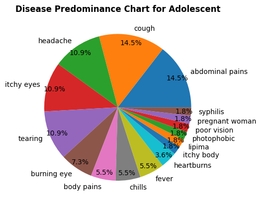

```python
#plotting a pie chart for the data

percentage = merge['frequency'] / merge['frequency'].sum() * 100

plt.pie(percentage, labels=merge.index, autopct='%1.1f%%', pctdistance=0.9)
plt.title('Disease Predominance Chart for Adolescent', fontdict= {'fontweight':'bold'})
plt.savefig('C:/Users/Daniel Appiah/Desktop/Adolescent_conditions_pie.png')


plt.show()
```

### Medication for adolescence

```python
#slicing medication columns into dfs
a3=pd.DataFrame(adolescent.loc[:,['Medication1']].value_counts()).sort_values('Medication1')
a3=a3.rename_axis('Medication')
b3=pd.DataFrame(adolescent.loc[:,['Medication2']].value_counts()).sort_values('Medication2')
b3= b3.rename_axis('Medication')
c3=pd.DataFrame(adolescent.loc[:,['Medication3']].value_counts()).sort_values('Medication3')
c_1=c3.rename_axis('Medication')

d3=pd.DataFrame(adolescent.loc[:,['Medication4']].value_counts()).sort_values('Medication4')
d3=d3.rename_axis('Medication')

e3=pd.DataFrame(adolescent.loc[:,['Medication5']].value_counts()).sort_values('Medication5')
e3=e3.rename_axis('Medication')

f3=pd.DataFrame(adolescent.loc[:,['Medication6']].value_counts()).sort_values('Medication6')
f3=f3.rename_axis('Medication')

g3=pd.DataFrame(adolescent.loc[:,['Medication7']].value_counts()).sort_values('Medication7')
g3=g3.rename_axis('Medication')
```

```python
# concatenating and editing dfs
new = pd.concat([a3, b3, c3,d3,e3,f3,g3])
new= new.rename(columns={0: 'frequency'})

new= new.rename({'A/L': 'A/L suspension'})
new= new.rename({' albendazole': 'albendazole suspension'})
new= new.rename({' amoxicillin': 'amoxicillin suspension'})
new= new.rename({' Cefuroxime': 'cefuroxime suspension'})
new= new.rename({' cetirizine': 'cetirizine suspension'})
new= new.rename({'Paracetamole suspension': 'paracetamol suspension'})
new= new.drop(' ')
new= new.drop('')
new= new.rename({' simple lintus suspension': 'simple lintus suspension'})
new= new.rename({' simple lintus supension': 'simple lintus suspension'})


new = new.reset_index()


new['Medication'] = new['Medication'].str.strip().str.lower()


new = new.groupby('Medication')['frequency'].sum()

new = pd.DataFrame(new)
new= new.sort_values('frequency', ascending=False)
```

```python
table7 = new.rename_axis('Medications')
table7.to_csv('C:/Users/Daniel Appiah/Desktop/adolescent_med_table.csv')

table7
```

| Medications | frequency |
| --- | --- |
| paracetamol | 10 |
| amoxicillin | 5 |
| omeprazole | 5 |
| vitamin c | 4 |
| amoxicillin suspension | 4 |
| folic acid | 3 |
| flagyl | 3 |
| epicrom | 3 |
| cool eyes | 2 |
| simple lintus suspension | 2 |
| mmt suspension | 2 |
| a/l suspension | 2 |
| a/l | 2 |
| cefuroxime | 2 |
| antacid | 2 |
| ciprofloxacin | 1 |
| cetirizine suspension | 1 |
| cefuroxime suspension | 1 |
| gutt ciprofloxacin | 1 |
| haematinic | 1 |
| ibuprofen | 1 |
| metronidazole | 1 |
| amoxiclav | 1 |
| albendazole suspension | 1 |
| penicillin | 1 |
| albendazole | 1 |
| cough | 1 |

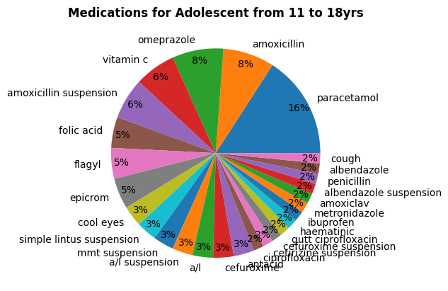

```python
plt.pie(new['frequency'],labels=new.index ,autopct='%1.0f%%',pctdistance=0.9)
plt.title('Medications for Adolescent from 11 to 18yrs', fontdict={'fontweight':'bold'})
plt.savefig('C:/Users/Daniel Appiah/Desktop/Adolescent_medication_pie.png')

plt.show()
```

### Adult from 19 to 40 years

```python
y_adult = data.loc['19-40']
y_adult.describe()
```

|  | AGE | RBS(mmol/L) | P(bpm) | Systolic BP | Diastolic BP |
| --- | --- | --- | --- | --- | --- |
| count | 34.000000 | 29.000000 | 32.00000 | 33.000000 | 33.000000 |
| mean | 29.205882 | 5.993103 | 82.93750 | 123.090909 | 75.272727 |
| std | 5.973575 | 1.380976 | 13.93519 | 24.716345 | 22.187092 |
| min | 18.000000 | 3.900000 | 57.00000 | 76.000000 | 55.000000 |
| 25% | 26.000000 | 5.400000 | 74.50000 | 109.000000 | 63.000000 |
| 50% | 30.000000 | 5.900000 | 83.50000 | 115.000000 | 66.000000 |
| 75% | 34.500000 | 6.800000 | 92.00000 | 131.000000 | 82.000000 |
| max | 38.000000 | 9.300000 | 114.00000 | 192.000000 | 163.000000 |

```python
y_adult.GENDER.value_counts()
```

```
Female    27
male       7
Name: GENDER, dtype: int64
```

We can see that they are a total of 34 with 27 females and 7 males with mean age of 29.

#### Disease condition analysis of adults from 19 to 40 years

```python
#Preparing the data
#slicing the 7 columns of conditions in dataframes
a4=pd.DataFrame(y_adult.loc[:,['Condition1']].value_counts()).sort_values('Condition1')
a4= a4.rename_axis('Condition2')
b4=pd.DataFrame(y_adult.loc[:,['Condition2']].value_counts()).sort_values('Condition2')
b4= b4.rename_axis('Condition2')
c4=pd.DataFrame(y_adult.loc[:,['Condition3']].value_counts()).sort_values('Condition3')
c4=c4.rename_axis('Condition2')

d4=pd.DataFrame(y_adult.loc[:,['Condition4']].value_counts()).sort_values('Condition4')
d4=d4.rename_axis('Condition2')

e4=pd.DataFrame(y_adult.loc[:,['Condition5']].value_counts()).sort_values('Condition5')
e4=e4.rename_axis('Condition2')

f4=pd.DataFrame(y_adult.loc[:,['Condition6']].value_counts()).sort_values('Condition6')
f4=f4.rename_axis('Condition2')

g4=pd.DataFrame(y_adult.loc[:,['Condition7']].value_counts()).sort_values('Condition7')
g4=g4.rename_axis('Condition2')
```

```python
#concatenating the dfs
merge1 = pd.concat([a4, b4, c4,d4,e4,f4,g4])
merge1 = merge1.rename(columns={0: 'frequency'})


merge1= merge1.rename({' abdominal pain': 'abdominal pains'})
merge1= merge1.rename({' burning sensation in the eye': 'burning eye'})
merge1= merge1.rename({' burning sensation': 'burning eye'})
merge1= merge1.rename({' burning sensation in eye': 'burning eye'})
merge1= merge1.rename({' eye discharge': 'tearing'})
merge1= merge1.rename({' hearburns': 'heartburns'})
merge1= merge1.rename({'itchy eye': 'itchy eyes'})
merge1= merge1.rename({'gritty and burning sensation in the eye': 'burning eye'})
merge1= merge1.rename({'Itching and burning sensation in the eye': 'burning eye'})
merge1= merge1.rename({'left eye problem': 'burning eye'})
merge1= merge1.rename({' night sweat': 'fever'})
merge1= merge1.rename({' waist pain': 'body pains'})
merge1= merge1.rename({' waist pains': 'body pains'})
merge1= merge1.rename({'waist pains': 'body pains'})
merge1= merge1.rename({' Bitter taste': 'loss of appetite'})
merge1= merge1.rename({' bitter taste': 'loss of appetite'})

merge1= merge1.rename({'gluacoma suspect': 'itchy eyes'})
merge1= merge1.rename({' itchy rashes': 'itchy body'})
merge1= merge1.drop(' ')
merge1= merge1.drop('')

merge1 = merge1.reset_index()


merge1['Condition2'] = merge1['Condition2'].str.strip().str.lower()


merge1 = merge1.groupby('Condition2')['frequency'].sum()

merge1 = pd.DataFrame(merge1)
merge1= merge1.sort_values('frequency', ascending= False)
```

```python
table3 = merge1.rename_axis('Condition')
table3.to_csv('C:/Users/Daniel Appiah/Desktop/19-40_ cond_table.csv')

table3
```

| Condition | frequency |
| --- | --- |
| body pains | 12 |
| chills | 8 |
| cough | 8 |
| headache | 8 |
| itchy eyes | 8 |
| abdominal pains | 6 |
| fever | 6 |
| tearing | 6 |
| burning eye | 5 |
| dizziness | 5 |
| known hpt | 5 |
| loss of appetite | 4 |
| heartburns | 3 |
| itchy body | 3 |
| runny nose | 3 |
| chest pains | 2 |

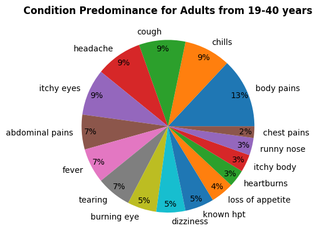

```python
plt.pie(merge1['frequency'],labels=merge1.index ,autopct='%1.0f%%', pctdistance=0.9)
plt.title('Condition Predominance for Adults from 19-40 years',fontdict={'fontweight':'bold'})
plt.savefig('C:/Users/Daniel Appiah/Desktop/19-40yrs_conditions_pie.png')

plt.show()
```

#### Medication Analysis

```python
# forming dfs from the medication columns
a11=pd.DataFrame(y_adult.loc[:,['Medication1']].value_counts()).sort_values('Medication1')
a11=a11.rename_axis('Medication2')
b11=pd.DataFrame(y_adult.loc[:,['Medication2']].value_counts()).sort_values('Medication2')
b11= b11.rename_axis('Medication2')
c11=pd.DataFrame(y_adult.loc[:,['Medication3']].value_counts()).sort_values('Medication3')
c11=c11.rename_axis('Medication2')

d11=pd.DataFrame(y_adult.loc[:,['Medication4']].value_counts()).sort_values('Medication4')
d11=d11.rename_axis('Medication2')

e11=pd.DataFrame(y_adult.loc[:,['Medication5']].value_counts()).sort_values('Medication5')
e11=e11.rename_axis('Medication2')

f11=pd.DataFrame(y_adult.loc[:,['Medication6']].value_counts()).sort_values('Medication6')
f11=f11.rename_axis('Medication2')

g11=pd.DataFrame(y_adult.loc[:,['Medication7']].value_counts()).sort_values('Medication7')
g11=g11.rename_axis('Medication2')
```

```python
#concatenating the dfs
combined = pd.concat([a11, b11, c11,d11,e11,f11,g11])
combined= combined.rename(columns={0: 'frequency'})

combined= combined.rename({'Amoxicilin': 'Amoxicillin'})
combined= combined.rename({' Amoxicilin': 'Amoxicillin'})

combined= combined.rename({'cetirizine suspension': 'cetirizine'})
combined= combined.rename({' cetirizine suspension': 'cetirizine'})

combined= combined.rename({' anatacid': 'antacid suspension'})
combined= combined.rename({' simple linters suspension': 'simple lintus suspension'})
combined= combined.rename({' heamatinic': 'haematinic'})
combined= combined.rename({' peniciliin': 'penicillin'})

combined = combined.reset_index()


combined['Medication2'] = combined['Medication2'].str.strip().str.lower()


combined = combined.groupby('Medication2')['frequency'].sum()

combined = pd.DataFrame(combined)
combined= combined.sort_values('frequency', ascending= False)
```

```python
table8 = combined.rename_axis('Medications')
table8.to_csv('C:/Users/Daniel Appiah/Desktop/yadult_med_table.csv')

table8
```

| Medications | frequency |
| --- | --- |
| amoxicillin | 11 |
| paracetamol | 11 |
| a/l | 10 |
| folic acid | 9 |
| ibuprofen | 7 |
| epicrom | 7 |
| cool eyes | 6 |
| omeprazole | 6 |
| flagyl | 6 |
| vitamin c | 6 |
| antacid suspension | 6 |
| cefuroxime | 5 |
| p alaxin | 5 |
| metronidazole | 5 |
| gutt ciprofloxacin | 4 |
| cetirizine | 4 |
| tramadol | 4 |
| haematinic | 4 |
| ciprofloxacin | 4 |
| simple lintus suspension | 3 |
| nifedipine | 3 |
| lisinopril | 2 |
| penicillin | 2 |
| amoxiclav | 1 |
| azithromycin | 1 |
| albendazole | 1 |
| vitamin b | 1 |
| diclo gel | 1 |

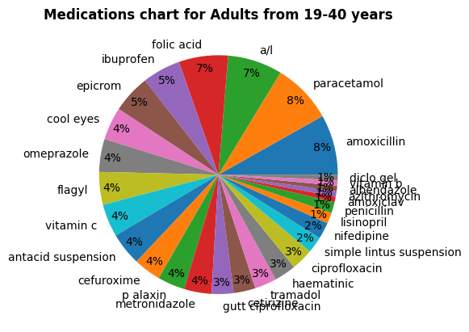

```python
plt.pie(combined['frequency'],labels=combined.index ,autopct='%1.0f%%', pctdistance=0.9)
plt.title('Medications chart for Adults from 19-40 years', fontdict={'fontweight':'bold'})
plt.savefig('C:/Users/Daniel Appiah/Desktop/19-40yrs_medications_pie.png')

plt.show()
```

## Analysis of adults from 41-60 years

```python
o_adults = data.loc['41-60']
o_adults.describe()
```

|  | AGE | RBS(mmol/L) | P(bpm) | Systolic BP | Diastolic BP |
| --- | --- | --- | --- | --- | --- |
| count | 30.000000 | 24.000000 | 29.000000 | 30.000000 | 30.000000 |
| mean | 48.100000 | 6.741667 | 83.344828 | 126.833333 | 77.766667 |
| std | 6.391535 | 1.993668 | 14.573155 | 23.581236 | 14.409488 |
| min | 40.000000 | 4.300000 | 62.000000 | 90.000000 | 53.000000 |
| 25% | 43.250000 | 5.175000 | 71.000000 | 110.250000 | 68.000000 |
| 50% | 47.500000 | 6.200000 | 80.000000 | 124.000000 | 74.000000 |
| 75% | 54.250000 | 7.925000 | 95.000000 | 135.500000 | 84.500000 |
| max | 59.000000 | 11.700000 | 107.000000 | 206.000000 | 118.000000 |

```python
o_adults['GENDER'].value_counts()
```

```
Female    17
male      13
Name: GENDER, dtype: int64
```

We could see there are 30 people within this range with 17 female and 13 males with mean age of 48

### Disease Condition Analysis

```python
#Preparing the data
#slicing the 7 columns of conditions in dataframes
a44=pd.DataFrame(o_adults.loc[:,['Condition1']].value_counts()).sort_values('Condition1')
a44= a44.rename_axis('Condition21')
b44=pd.DataFrame(o_adults.loc[:,['Condition2']].value_counts()).sort_values('Condition2')
b44= b44.rename_axis('Condition21')
c44=pd.DataFrame(o_adults.loc[:,['Condition3']].value_counts()).sort_values('Condition3')
c44=c44.rename_axis('Condition21')

d44=pd.DataFrame(o_adults.loc[:,['Condition4']].value_counts()).sort_values('Condition4')
d44=d44.rename_axis('Condition21')

e44=pd.DataFrame(o_adults.loc[:,['Condition5']].value_counts()).sort_values('Condition5')
e44=e44.rename_axis('Condition21')

f44=pd.DataFrame(o_adults.loc[:,['Condition6']].value_counts()).sort_values('Condition6')
f44=f44.rename_axis('Condition21')

g44=pd.DataFrame(o_adults.loc[:,['Condition7']].value_counts()).sort_values('Condition7')
g44=g44.rename_axis('Condition21')
```

```python
#concatenating the slices
merge11 = pd.concat([a44, b44, c44,d44,e44,f44,g44])
merge11 = merge11.rename(columns={0: 'frequency'})


merge11= merge11.rename({' abdominal pain ': 'abdominal pains'})
merge11= merge11.rename({'Burning sensation in the eye': 'burning eye'})
merge11= merge11.rename({'burning sensation in the eyes': 'burning eye'})
merge11= merge11.rename({' burning sensation in the eyes': 'burning eye'})
merge11= merge11.rename({'eye discharge': 'tearing'})
merge11= merge11.rename({' hearburns': 'heartburns'})
merge11= merge11.rename({'itchy eye': 'itchy eyes'})
merge11= merge11.rename({' gritty and burning sensation in the eye': 'burning eye'})
merge11= merge11.rename({'Itching and burning sensation in the eye': 'burning eye'})
merge11= merge11.rename({'left eye problem': 'burning eye'})
merge11= merge11.rename({' night sweat': 'fever'})
merge11= merge11.rename({' waist pain': 'body pains'})
merge11= merge11.rename({' waist pains': 'body pains'})
merge11= merge11.rename({'waist pains': 'body pains'})
merge11= merge11.rename({' HPT': 'known hpt'})
merge11= merge11.rename({'tears in eyes': 'tearing'})
merge11= merge11.rename({'stomach infection': 'infection'})
merge11= merge11.rename({'chest pains': 'body pains'})
merge11= merge11.rename({'Stomach infection': 'infection '})


merge11= merge11.rename({'gluacoma suspect': 'itchy eyes'})
merge11= merge11.rename({' itchy rashes': 'itchy body'})
merge11= merge11.rename({'  blurred vision': 'poor vision'})
merge11= merge11.rename({'blurred vision': 'poor vision'})




merge11 = merge11.reset_index()


merge11['Condition21'] = merge11['Condition21'].str.strip().str.lower()


merge11 = merge11.groupby('Condition21')['frequency'].sum()

merge11 = pd.DataFrame(merge11)
merge11= merge11.sort_values('frequency',ascending=False)
merge11.index
```

```
Index(['body pains', 'tearing', 'poor vision', 'myopia', 'headache',
       'itchy eyes', 'abdominal pains', 'chills', 'cough', 'malaria',
       'burning eye', 'infection', 'known hpt', 'itchy body', 'frequent urine',
       'easy fatigue', 'dizziness', 'known diabetes', 'loss of appetite',
       'runny nose', 'swollen leg'],
      dtype='object', name='Condition21')
```

```python
table4 = merge11.rename_axis('Condition')
table4.to_csv('C:/Users/Daniel Appiah/Desktop/40-60_ cond_table.csv')

table4
```

| Condition | frequency |
| --- | --- |
| body pains | 15 |
| tearing | 7 |
| poor vision | 6 |
| myopia | 6 |
| headache | 5 |
| itchy eyes | 5 |
| abdominal pains | 4 |
| chills | 4 |
| cough | 3 |
| malaria | 3 |
| burning eye | 3 |
| infection | 2 |
| known hpt | 2 |
| itchy body | 2 |
| frequent urine | 1 |
| easy fatigue | 1 |
| dizziness | 1 |
| known diabetes | 1 |
| loss of appetite | 1 |
| runny nose | 1 |
| swollen leg | 1 |

With the body pains, chest and waist and other special parts must be factored. Same for the infection

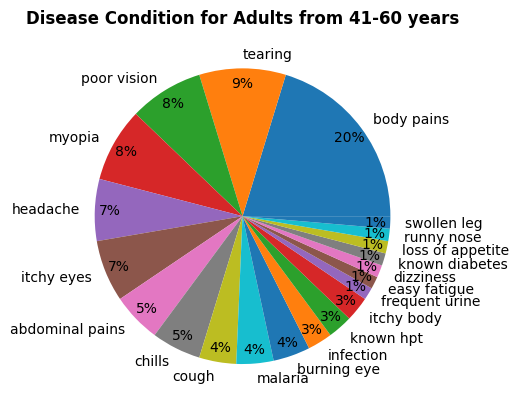

```python
plt.pie(merge11['frequency'],labels=merge11.index ,autopct='%1.0f%%', pctdistance=0.9)
plt.title('Disease Condition for Adults from 41-60 years', fontdict={'fontweight':'bold'})
plt.savefig('C:/Users/Daniel Appiah/Desktop/41-60yrs_conditions_pie.png')

plt.show()
```

### Medication Analysis for 41-60yrs

```python
#forming dfs from medication columns
aa11=pd.DataFrame(o_adults.loc[:,['Medication1']].value_counts()).sort_values('Medication1')
aa11=aa11.rename_axis('Medications3')
bb11=pd.DataFrame(o_adults.loc[:,['Medication2']].value_counts()).sort_values('Medication2')
bb11= bb11.rename_axis('Medications3')
cc11=pd.DataFrame(o_adults.loc[:,['Medication3']].value_counts()).sort_values('Medication3')
cc11=cc11.rename_axis('Medications3')

dd11=pd.DataFrame(o_adults.loc[:,['Medication4']].value_counts()).sort_values('Medication4')
dd11=dd11.rename_axis('Medications3')

ee11=pd.DataFrame(o_adults.loc[:,['Medication5']].value_counts()).sort_values('Medication5')
ee11=ee11.rename_axis('Medications3')

ff11=pd.DataFrame(o_adults.loc[:,['Medication6']].value_counts()).sort_values('Medication6')
ff11=ff11.rename_axis('Medications3')

gg11=pd.DataFrame(o_adults.loc[:,['Medication7']].value_counts()).sort_values('Medication7')
gg11=gg11.rename_axis('Medications3')
```

```python
#merging the dfs
combined1 = pd.concat([aa11, bb11, cc11,dd11,ee11,ff11,gg11])
combined1= combined1.rename(columns={0: 'frequency'})

combined1= combined1.rename({'Amoxicilin': 'Amoxicillin'})
combined1= combined1.rename({' Amoxicilin': 'Amoxicillin'})

combined1= combined1.rename({'cetirizine suspension': 'cetirizine'})
combined1= combined1.rename({' cetirizine suspension': 'cetirizine'})

combined1= combined1.rename({' anatacid': 'antacid suspension'})
combined1= combined1.rename({' simple linters suspension': 'simple lintus suspension'})
combined1= combined1.rename({' simple linctus suspension': 'simple lintus suspension'})

combined1= combined1.rename({' Heamatinic': 'haematinic'})
combined1= combined1.rename({' peniciliin': 'penicillin'})
combined1= combined1.rename({' cefufoxime': 'cefuroxime'})
combined1= combined1.rename({' Nifidipin': 'Nifedipine'})
combined1= combined1.rename({' Vitamins C': 'vitamin C'})


combined1 = combined1.reset_index()


combined1['Medications3'] = combined1['Medications3'].str.strip().str.lower()


combined1 = combined1.groupby('Medications3')['frequency'].sum()

combined1 = pd.DataFrame(combined1)
combined1= combined1.sort_values('frequency', ascending=False)
```

```python
table8 = combined1.rename_axis('Condition')
table8.to_csv('C:/Users/Daniel Appiah/Desktop/41-60_ med_table.csv')

table8
```

| Condition | frequency |
| --- | --- |
| paracetamol | 9 |
| tramadol | 9 |
| spectacle | 7 |
| amoxiclav | 7 |
| folic acid | 6 |
| ibuprofen | 6 |
| a/l | 6 |
| vitamin c | 5 |
| albendazole | 5 |
| epicrom | 5 |
| diclo gel | 4 |
| omeprazole | 4 |
| flagyl | 4 |
| cefuroxime | 4 |
| cool eyes | 4 |
| ciprofloxacin | 3 |
| gutt ciprofloxacin | 3 |
| haematinic | 3 |
| ear drop | 2 |
| amoxicillin | 2 |
| simple lintus suspension | 2 |
| metronidazole | 2 |
| cetirizine | 2 |
| zinc tablet | 1 |
| glibenclamide | 1 |
| nifedipine | 1 |
| metformin | 1 |
| lisinopril | 1 |
| furosemide | 1 |
| azithromycin | 1 |
| antacid | 1 |
| zinwrit | 1 |

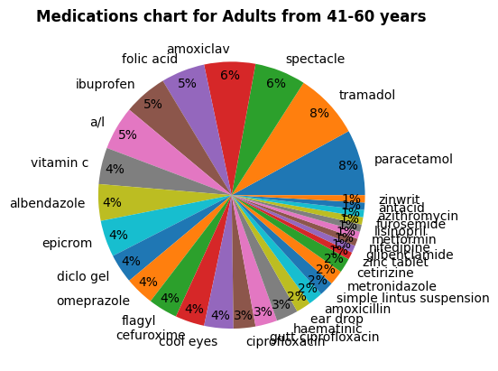

```python
plt.pie(combined1['frequency'],labels=combined1.index ,autopct='%1.0f%%', pctdistance=0.9)
plt.title('Medications chart for Adults from 41-60 years', fontdict={'fontweight':'bold'})
plt.savefig('C:/Users/Daniel Appiah/Desktop/41-60 years_medications_pie.png')

plt.show()
```

## Analysis for adults above 60 years

```python
above_60 = data.loc['60+']
above_60.describe()
```

|  | AGE | RBS(mmol/L) | P(bpm) | Systolic BP | Diastolic BP |
| --- | --- | --- | --- | --- | --- |
| count | 18.000000 | 15.000000 | 17.000000 | 17.000000 | 17.000000 |
| mean | 69.222222 | 5.980000 | 77.352941 | 137.647059 | 73.764706 |
| std | 10.882017 | 1.257662 | 14.004201 | 26.253431 | 9.705214 |
| min | 60.000000 | 3.800000 | 57.000000 | 102.000000 | 50.000000 |
| 25% | 61.250000 | 5.200000 | 65.000000 | 119.000000 | 70.000000 |
| 50% | 64.500000 | 6.000000 | 78.000000 | 133.000000 | 75.000000 |
| 75% | 74.250000 | 6.700000 | 87.000000 | 154.000000 | 80.000000 |
| max | 102.000000 | 9.000000 | 102.000000 | 196.000000 | 88.000000 |

```python
above_60['GENDER'].value_counts()
```

```
male      10
Female     8
Name: GENDER, dtype: int64
```

We could see that there are 18 people, 10 males and 8 females with mean age of 69.

### Disease Condition Analysis

```python
#forming dfs from column slices
a444=pd.DataFrame(above_60.loc[:,['Condition1']].value_counts()).sort_values('Condition1')
a444= a444.rename_axis('Condition7')
b444=pd.DataFrame(above_60.loc[:,['Condition2']].value_counts()).sort_values('Condition2')
b444= b444.rename_axis('Condition7')
c444=pd.DataFrame(above_60.loc[:,['Condition3']].value_counts()).sort_values('Condition3')
c444=c444.rename_axis('Condition7')

d444=pd.DataFrame(above_60.loc[:,['Condition4']].value_counts()).sort_values('Condition4')
d444=d444.rename_axis('Condition7')

e444=pd.DataFrame(above_60.loc[:,['Condition5']].value_counts()).sort_values('Condition5')
e444=e444.rename_axis('Condition7')

f444=pd.DataFrame(above_60.loc[:,['Condition6']].value_counts()).sort_values('Condition6')
f444=f444.rename_axis('Condition7')

g444=pd.DataFrame(above_60.loc[:,['Condition7']].value_counts()).sort_values('Condition7')
g444=g444.rename_axis('Condition7')
```

```python
#concatenating dfs
med1 = pd.concat([a444, b444, c444,d444,e444,f444,g444])
med1 = med1.rename(columns={0: 'frequency'})


med1= med1.rename({' abdominal pain ': 'abdominal pains'})
med1= med1.rename({'Burning sensation in the eye': 'burning eye'})
med1= med1.rename({'burning sensation in eye': 'burning eye'})
med1= med1.rename({' burning sensation in eyes': 'burning eye'})
med1= med1.rename({'eye discharge': 'tearing'})
med1= med1.rename({' hearburns': 'heartburns'})
med1= med1.rename({'itchy eyes': 'itchy eyes'})
med1= med1.rename({'Itchy eye': 'itchy eyes'})
med1= med1.rename({'itchy eye': 'itchy eyes'})
med1= med1.rename({'blurred vision': 'poor vision'})
med1= med1.rename({'Blurred Vision': 'poor vision'})
med1= med1.rename({'Blurred vision': 'poor vision'})
med1= med1.rename({' blurred vision': 'poor vision'})



med1= med1.rename({' gritty and burning sensation in the eye': 'burning eye'})
med1= med1.rename({'Itching and burning sensation in the eye': 'burning eye'})
med1= med1.rename({'left eye problem': 'burning eye'})
med1= med1.rename({' night sweat': 'fever'})
med1= med1.rename({' waist pain': 'body pains'})
med1= med1.rename({' waist pains': 'body pains'})
med1= med1.rename({'waist pains': 'body pains'})
med1= med1.rename({' HPT': 'known hpt'})
med1= med1.rename({'tears in eyes': 'tearing'})
med1= med1.rename({'stomach infection': 'infection'})
med1= med1.rename({'chest pains': 'body pains'})
med1= med1.rename({'stomach infection': 'infection '})


med1= med1.rename({'gluacoma suspect': 'itchy eyes'})
med1= med1.rename({' itchy rashes': 'itchy body'})
med1= med1.rename({'eye  discharge': 'tearing'})
med1= med1.rename({'eye discharge': 'tearing'})
med1= med1.rename({' eye discharge': 'tearing'})

med1= med1.rename({' general body pains': 'body pains'})
med1= med1.rename({' joint pains': 'body pains'})
med1= med1.rename({'joints pains': 'body pains'})
med1= med1.rename({' knee pains': 'body pains'})
med1= med1.rename({' leg pains': 'body pains'})
med1= med1.drop(' ')
med1= med1.drop('')


med1 = med1.reset_index()


med1['Condition7'] = med1['Condition7'].str.strip().str.lower()


med1 = med1.groupby('Condition7')['frequency'].sum()

med1 = pd.DataFrame(med1)
med1= med1.sort_values('frequency', ascending=False)
```

```python
table5 = med1.rename_axis('Condition')
table5.to_csv('C:/Users/Daniel Appiah/Desktop/above 60_ cond_table.csv')

table5
```

| Condition | frequency |
| --- | --- |
| body pains | 13 |
| poor vision | 8 |
| itchy eyes | 7 |
| tearing | 5 |
| cough | 3 |
| cataract | 3 |
| itchy body | 3 |
| known hpt | 2 |
| dizziness | 1 |
| fever | 1 |
| headache | 1 |
| infections | 1 |
| burning eye | 1 |
| myopia | 1 |
| numbness | 1 |
| runny nose | 1 |
| syphillis | 1 |

### Medication Analysis

```python
#forming dfs from medication columns
an=pd.DataFrame(above_60.loc[:,['Medication1']].value_counts()).sort_values('Medication1')
an=an.rename_axis('Medications6')
bn=pd.DataFrame(above_60.loc[:,['Medication2']].value_counts()).sort_values('Medication2')
bn= bn.rename_axis('Medications6')
cn=pd.DataFrame(above_60.loc[:,['Medication3']].value_counts()).sort_values('Medication3')
cn=cn.rename_axis('Medications6')

dn=pd.DataFrame(above_60.loc[:,['Medication4']].value_counts()).sort_values('Medication4')
dn=dn.rename_axis('Medications6')

en=pd.DataFrame(above_60.loc[:,['Medication5']].value_counts()).sort_values('Medication5')
en=en.rename_axis('Medications6')

fn=pd.DataFrame(above_60.loc[:,['Medication6']].value_counts()).sort_values('Medication6')
fn=fn.rename_axis('Medications6')

gn=pd.DataFrame(above_60.loc[:,['Medication7']].value_counts()).sort_values('Medication7')
gn=gn.rename_axis('Medications6')
```

```python
# concatenating slices
combination = pd.concat([an, bn, cn,dn,en,fn,gn])
combination= combination.rename(columns={0: 'frequency'})

combination= combination.rename({'Amoxicilin': 'Amoxicillin'})
combination= combination.rename({' Amoxicilin': 'Amoxicillin'})

combination= combination.rename({'cetirizine suspension': 'cetirizine'})
combination= combination.rename({' cetirizine suspension': 'cetirizine'})

combination= combination.rename({' anatacid': 'antacid suspension'})
combination= combination.rename({' simple linters suspension': 'simple lintus suspension'})
combination= combination.rename({' simple linctus suspension': 'simple lintus suspension'})

combination= combination.rename({' heamatinic': 'haematinic'})
combination= combination.rename({' peniciliin': 'penicillin'})
combination= combination.rename({' cefufoxime': 'cefuroxime'})
combination= combination.rename({' Nifidipin': 'Nifedipine'})
combination= combination.rename({' Vitamins C': 'vitamin C'})
combination= combination.rename({' Foli acid': 'folic acid'})
combination= combination.rename({' paracematol': 'paracetamol'})
combination= combination.rename({' Ipubofren': 'ibuprofen'})


combination = combination.reset_index()


combination['Medications6'] = combination['Medications6'].str.strip().str.lower()


combination = combination.groupby('Medications6')['frequency'].sum()

combination = pd.DataFrame(combination)
combination = combination.sort_values('frequency', ascending = False)
```

```python
table9 = combination.rename_axis('Condition')
table9.to_csv('C:/Users/Daniel Appiah/Desktop/above 60_ med_table.csv')

table9
```

| Condition | frequency |
| --- | --- |
| ibuprofen | 7 |
| diclo gel | 6 |
| vitamin c | 4 |
| cool eyes | 3 |
| epicrom | 3 |
| folic acid | 3 |
| a/l | 2 |
| cetirizine | 2 |
| tramadol | 2 |
| amoxiclav | 2 |
| paracetamol | 2 |
| gutt ciprofloxacin | 2 |
| cefuroxime | 2 |
| nifidipine | 1 |
| spectacles | 1 |
| simple lintus suspension | 1 |
| penicillin | 1 |
| p alaxin | 1 |
| omeprazole | 1 |
| bendro | 1 |
| lisinopril | 1 |
| haematinic | 1 |
| albendazole | 1 |
| flagyl | 1 |
| amoxicillin | 1 |
| antacid | 1 |
| ciprofloxacin | 1 |
| amitrypthylene | 1 |

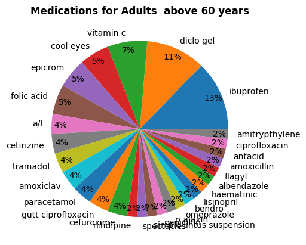

```python
plt.pie(combination['frequency'],labels=combination.index ,autopct='%1.0f%%',pctdistance=0.9)
plt.title('Medications for Adults  above 60 years', fontdict={'fontweight':'bold'})
plt.savefig('C:/Users/Daniel Appiah/Desktop/ above 60_medications_pie.png')

plt.show()
```

### Data With Unknown Age

```python
Unknown = data.loc['Unknown']
Unknown.describe()
```

|  | AGE | RBS(mmol/L) | P(bpm) | Systolic BP | Diastolic BP |
| --- | --- | --- | --- | --- | --- |
| count | 0.0 | 3.000000 | 4.000000 | 4.000000 | 4.00000 |
| mean | NaN | 5.066667 | 84.250000 | 152.000000 | 85.25000 |
| std | NaN | 0.550757 | 14.997222 | 50.813384 | 18.13606 |
| min | NaN | 4.500000 | 64.000000 | 107.000000 | 72.00000 |
| 25% | NaN | 4.800000 | 78.250000 | 130.250000 | 75.75000 |
| 50% | NaN | 5.100000 | 87.000000 | 138.000000 | 78.50000 |
| 75% | NaN | 5.350000 | 93.000000 | 159.750000 | 88.00000 |
| max | NaN | 5.600000 | 99.000000 | 225.000000 | 112.00000 |

```python
Unknown['GENDER'].value_counts()
```

```
male      5
Female    5
Name: GENDER, dtype: int64
```

### Condition Analysis

```python
a0=pd.DataFrame(Unknown.loc[:,['Condition1']].value_counts()).sort_values('Condition1')
a0= a0.rename_axis('Condition7')
b0=pd.DataFrame(Unknown.loc[:,['Condition2']].value_counts()).sort_values('Condition2')
b0= b0.rename_axis('Condition7')
c0=pd.DataFrame(Unknown.loc[:,['Condition3']].value_counts()).sort_values('Condition3')
c0=c0.rename_axis('Condition7')

d0=pd.DataFrame(Unknown.loc[:,['Condition4']].value_counts()).sort_values('Condition4')
d0=d0.rename_axis('Condition7')

e0=pd.DataFrame(Unknown.loc[:,['Condition5']].value_counts()).sort_values('Condition5')
e0=e0.rename_axis('Condition7')

f0=pd.DataFrame(Unknown.loc[:,['Condition6']].value_counts()).sort_values('Condition6')
f0=f0.rename_axis('Condition7')

g0=pd.DataFrame(Unknown.loc[:,['Condition7']].value_counts()).sort_values('Condition7')
g0=g0.rename_axis('Condition7')
```

```python
med2 = pd.concat([a0, b0, c0,d0,e0,f0,g0])
med2 = med2.rename(columns={0: 'frequency'})


med2= med2.rename({' abdominal pain ': 'abdominal pains'})
med2= med2.rename({'Burning sensation in the eyes': 'burning eye'})
med2= med2.rename({'burning sensation in eye': 'burning eye'})
med2= med2.rename({' burning sensation in the eyes': 'burning eye'})
med2= med2.rename({'eye discharge': 'tearing'})
med2= med2.rename({' hearburns': 'heartburns'})
med2= med2.rename({'itchy eyes': 'itchy eyes'})
med2= med2.rename({'Itchy eye': 'itchy eyes'})
med2= med2.rename({'itchy eye': 'itchy eyes'})
med2= med2.rename({'Blurred vision': 'burning eye'})


med2= med2.rename({' gritty and burning sensation in the eye': 'burning eye'})
med2= med2.rename({'Itching and burning sensation in the eye': 'burning eye'})
med2= med2.rename({'left eye problem': 'burning eye'})
med2= med2.rename({' night sweat': 'fever'})
med2= med2.rename({' waist pain': 'body pains'})
med2= med2.rename({' waist pains': 'body pains'})
med2= med2.rename({'waist pains': 'body pains'})
med2= med2.rename({' HPT': 'known hpt'})
med2= med2.rename({'tears in eyes': 'tearing'})
med2= med2.rename({'stomach infection': 'infection'})
med2= med2.rename({'chest pains': 'body pains'})
med2= med2.rename({'stomach infection': 'infection '})


med2= med2.rename({'gluacoma suspect': 'itchy eyes'})
med2= med2.rename({' itchy rashes': 'itchy body'})
med2= med2.rename({'eye  discharge': 'tearing'})
med2= med2.rename({'eye discharge': 'tearing'})
med2= med2.rename({' eye discharge': 'tearing'})

med2= med2.rename({' general body pains': 'body pains'})
med2= med2.rename({' joint pains': 'body pains'})
med2= med2.rename({'joints pains': 'body pains'})
med2= med2.rename({' knee pains': 'body pains'})
med2= med2.rename({' leg pains': 'body pains'})
med2= med2.drop(' ')
med2= med2.drop('')


med2 = med2.reset_index()


med2['Condition7'] = med2['Condition7'].str.strip().str.lower()


med2 = med2.groupby('Condition7')['frequency'].sum()

med2 = pd.DataFrame(med2)
```

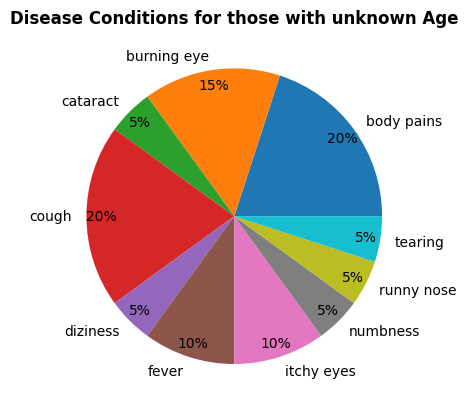

```python
plt.pie(med2['frequency'],labels=med2.index ,autopct='%1.0f%%',pctdistance=0.9)
plt.title('Disease Conditions for those with unknown Age',fontdict={'fontweight':'bold'})
plt.savefig('C:/Users/Daniel Appiah/Desktop/unknown_conditions_pie.png')

plt.show()
```

### Medication Analysis

```python
an1=pd.DataFrame(Unknown.loc[:,['Medication1']].value_counts()).sort_values('Medication1')

an1=an1.rename_axis('Medications67')
bn1=pd.DataFrame(Unknown.loc[:,['Medication2']].value_counts()).sort_values('Medication2')
bn1= bn1.rename_axis('Medications67')
cn1=pd.DataFrame(Unknown.loc[:,['Medication3']].value_counts()).sort_values('Medication3')
cn1=cn1.rename_axis('Medications67')

dn1=pd.DataFrame(Unknown.loc[:,['Medication4']].value_counts()).sort_values('Medication4')
dn1=dn1.rename_axis('Medications67')

en1=pd.DataFrame(Unknown.loc[:,['Medication5']].value_counts()).sort_values('Medication5')
en1=en1.rename_axis('Medications67')

fn1=pd.DataFrame(Unknown.loc[:,['Medication6']].value_counts()).sort_values('Medication6')
fn1=fn1.rename_axis('Medications67')

gn1=pd.DataFrame(Unknown.loc[:,['Medication7']].value_counts()).sort_values('Medication7')
gn1=gn1.rename_axis('Medications67')
```

```python
combinationss = pd.concat([an1, bn1, cn1,dn1,en1,fn1,gn1])
combinationss= combinationss.rename(columns={0: 'frequency'})

combinationss= combinationss.rename({'Amoxicilin': 'Amoxicillin'})
combinationss= combinationss.rename({' Amoxicilin': 'Amoxicillin'})

combinationss= combinationss.rename({'cetirizine suspension': 'cetirizine'})
combinationss= combinationss.rename({' cetirizine suspension': 'cetirizine'})

combinationss= combinationss.rename({' anatacid': 'antacid suspension'})
combinationss= combinationss.rename({' simple linters suspension': 'simple lintus suspension'})
combinationss= combinationss.rename({' simple linctus suspension': 'simple lintus suspension'})

combinationss= combinationss.rename({' heamatinic': 'haematinic'})
combinationss= combinationss.rename({' peniciliin': 'penicillin'})
combinationss= combinationss.rename({' cefufoxime': 'cefuroxime'})
combinationss= combinationss.rename({' Nifidipin': 'Nifedipine'})
combinationss= combinationss.rename({' Vitamins C': 'vitamin C'})
combinationss= combinationss.rename({' Foli acid': 'folic acid'})
combinationss= combinationss.rename({' paracematol': 'paracetamol'})
combinationss= combinationss.rename({' Ipubofren': 'ibuprofen'})


combinationss = combinationss.reset_index()


combinationss['Medications67'] = combinationss['Medications67'].str.strip().str.lower()


combinationss = combinationss.groupby('Medications67')['frequency'].sum()

combinationss = pd.DataFrame(combinationss)
```

```python
table9 = combinationss.rename_axis('Condition')
table9= table9.sort_values('frequency', ascending = False)
table9.to_csv('C:/Users/Daniel Appiah/Desktop/unknown_ medication_table.csv')

table9
```

| Condition | frequency |
| --- | --- |
| vitamin c | 5 |
| cool eyes | 4 |
| tramadol | 4 |
| amoxicillin | 3 |
| a/l | 2 |
| cefuroxime | 2 |
| diclo gel | 2 |
| epicrom | 2 |
| ibuprofen | 2 |
| paracetamol | 2 |
| amoxicillin suspension | 1 |
| flagyl | 1 |
| folic acid | 1 |
| haematinic | 1 |
| nifedipine | 1 |

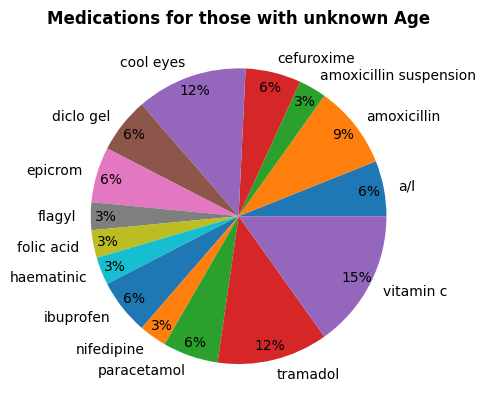

```python
plt.pie(combinationss['frequency'],labels=combinationss.index ,autopct='%1.0f%%',pctdistance=0.9)
plt.title('Medications for those with unknown Age',fontdict={'fontweight':'bold'})
plt.savefig('C:/Users/Daniel Appiah/Desktop/unknown_medications_pie.png')

plt.show()
```

## Overall Conditions analysis

```python
data1 =merged_df.rename_axis('disease')
data2 =merge.rename_axis('disease')
data3 =merge1.rename_axis('disease')
data4 =merge11.rename_axis('disease')
data5 =med1.rename_axis('disease')
data6 =med2.rename_axis('disease')
all_conditions = pd.concat([data1, data2, data3, data4, data5, data6])

all_conditions= all_conditions.rename({'diziness': 'dizziness'})

all_conditions.index
```

```
Index(['fever', 'cough', 'abdominal pains', 'headache', 'rashes',
       'allergic reaction', 'diarrhoea', 'ear pain', 'itchy body',
       'loss of appetite', 'runny nose', 'sore on the leg',
       'stomach infection', 'vomiting', 'abdominal pains', 'cough', 'headache',
       'itchy eyes', 'tearing', 'burning eye', 'body pains', 'chills', 'fever',
       'heartburns', 'itchy body', 'lipima', 'photophobic', 'poor vision',
       'pregnant woman', 'syphilis', 'body pains', 'chills', 'cough',
       'headache', 'itchy eyes', 'abdominal pains', 'fever', 'tearing',
       'burning eye', 'dizziness', 'known hpt', 'loss of appetite',
       'heartburns', 'itchy body', 'runny nose', 'chest pains', 'body pains',
       'tearing', 'poor vision', 'myopia', 'headache', 'itchy eyes',
       'abdominal pains', 'chills', 'cough', 'malaria', 'burning eye',
       'infection', 'known hpt', 'itchy body', 'frequent urine',
       'easy fatigue', 'dizziness', 'known diabetes', 'loss of appetite',
       'runny nose', 'swollen leg', 'body pains', 'poor vision', 'itchy eyes',
       'tearing', 'cough', 'cataract', 'itchy body', 'known hpt', 'dizziness',
       'fever', 'headache', 'infections', 'burning eye', 'myopia', 'numbness',
       'runny nose', 'syphillis', 'body pains', 'burning eye', 'cataract',
       'cough', 'dizziness', 'fever', 'itchy eyes', 'numbness', 'runny nose',
       'tearing'],
      dtype='object', name='disease')
```

```python
data6.index
```

```
Index(['body pains', 'burning eye', 'cataract', 'cough', 'diziness', 'fever',
       'itchy eyes', 'numbness', 'runny nose', 'tearing'],
      dtype='object', name='disease')
```

```python
all_conditions = all_conditions.reset_index()
all_conditions['disease'] = all_conditions['disease'].str.strip().str.lower()


all_conditions = all_conditions.groupby('disease')['frequency'].sum()

all_conditions = pd.DataFrame(all_conditions)
all_conditions = all_conditions.sort_values('frequency', ascending = False)#, ascending=False)



all_conditions
```

| disease | frequency |
| --- | --- |
| body pains | 47 |
| cough | 36 |
| itchy eyes | 28 |
| fever | 28 |
| tearing | 25 |
| abdominal pains | 25 |
| headache | 24 |
| burning eye | 16 |
| chills | 15 |
| poor vision | 15 |
| itchy body | 10 |
| known hpt | 9 |
| dizziness | 8 |
| myopia | 7 |
| runny nose | 7 |
| loss of appetite | 6 |
| heartburns | 5 |
| cataract | 4 |
| malaria | 3 |
| rashes | 3 |
| infection | 2 |
| numbness | 2 |
| chest pains | 2 |
| syphillis | 1 |
| sore on the leg | 1 |
| syphilis | 1 |
| pregnant woman | 1 |
| swollen leg | 1 |
| stomach infection | 1 |
| lipima | 1 |
| photophobic | 1 |
| known diabetes | 1 |
| allergic reaction | 1 |
| infections | 1 |
| frequent urine | 1 |
| easy fatigue | 1 |
| ear pain | 1 |
| diarrhoea | 1 |
| vomiting | 1 |

```python
#creating percentage column for the overall disease conditions

percentage = all_conditions['frequency'] / all_conditions['frequency'].sum() * 100
all_conditions['percentage']= percentage
disease_percentage = pd.DataFrame(all_conditions['percentage'])
disease_percentage.to_csv('C:/Users/Daniel Appiah/Desktop/disease frequncy.csv')
disease_percentage
```

| disease | percentage |
| --- | --- |
| body pains | 13.702624 |
| cough | 10.495627 |
| itchy eyes | 8.163265 |
| fever | 8.163265 |
| tearing | 7.288630 |
| abdominal pains | 7.288630 |
| headache | 6.997085 |
| burning eye | 4.664723 |
| chills | 4.373178 |
| poor vision | 4.373178 |
| itchy body | 2.915452 |
| known hpt | 2.623907 |
| dizziness | 2.332362 |
| myopia | 2.040816 |
| runny nose | 2.040816 |
| loss of appetite | 1.749271 |
| heartburns | 1.457726 |
| cataract | 1.166181 |
| malaria | 0.874636 |
| rashes | 0.874636 |
| infection | 0.583090 |
| numbness | 0.583090 |
| chest pains | 0.583090 |
| syphillis | 0.291545 |
| sore on the leg | 0.291545 |
| syphilis | 0.291545 |
| pregnant woman | 0.291545 |
| swollen leg | 0.291545 |
| stomach infection | 0.291545 |
| lipima | 0.291545 |
| photophobic | 0.291545 |
| known diabetes | 0.291545 |
| allergic reaction | 0.291545 |
| infections | 0.291545 |
| frequent urine | 0.291545 |
| easy fatigue | 0.291545 |
| ear pain | 0.291545 |
| diarrhoea | 0.291545 |
| vomiting | 0.291545 |

A total of 39 disease conditions were encountered

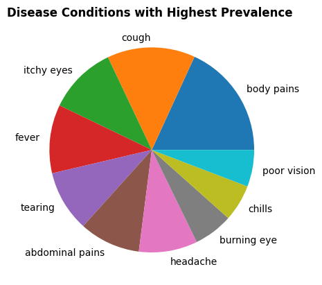

```python
#pie chart for top ten disease condition

top_ten = disease_percentage['percentage'][0:10]

plt.pie(top_ten,labels=top_ten.index )
plt.title('Disease Conditions with Highest Prevalence ',fontdict={'fontweight':'bold'})
plt.savefig('C:/Users/Daniel Appiah/Desktop/Overall Disease_pie.png')

plt.show()
```

### Overall Medication analysis

```python
# contatenating all the age ranged medications

dataset1 =merged.rename_axis('medicine')
dataset2 =new.rename_axis('medicine')
dataset3 =combined.rename_axis('medicine')
dataset4 =combined1.rename_axis('medicine')
dataset5 =combination.rename_axis('medicine')
dataset6 =combinationss.rename_axis('medicine')
all_medications = pd.concat([dataset1, dataset2, dataset3, dataset4, dataset5, dataset6])
all_medications.index
all_medications= all_medications.rename({'cough': 'simple lintus suspension'})
```

```python
#grouping and finding the frequency of medications
all_medications = all_medications.reset_index()
all_medications['medicine'] = all_medications['medicine'].str.strip().str.lower()


all_medications = all_medications.groupby('medicine')['frequency'].sum()

all_medications = pd.DataFrame(all_medications)
all_medications = all_medications.sort_values('frequency', ascending = False)


all_medications
```

| medicine | frequency |
| --- | --- |
| paracetamol | 46 |
| vitamin c | 28 |
| ibuprofen | 23 |
| a/l | 22 |
| folic acid | 22 |
| amoxicillin | 22 |
| flagyl | 21 |
| epicrom | 20 |
| cool eyes | 19 |
| tramadol | 19 |
| omeprazole | 16 |
| cefuroxime | 15 |
| diclo gel | 13 |
| paracetamol suspension | 12 |
| cetirizine suspension | 12 |
| a/l suspension | 11 |
| amoxiclav | 11 |
| haematinic | 10 |
| gutt ciprofloxacin | 10 |
| ciprofloxacin | 9 |
| simple lintus suspension | 9 |
| albendazole | 8 |
| amoxicillin suspension | 8 |
| cetirizine | 8 |
| metronidazole | 8 |
| spectacle | 7 |
| cefuroxime suspension | 7 |
| p alaxin | 6 |
| antacid suspension | 6 |
| nifedipine | 5 |
| antacid | 4 |
| lisinopril | 4 |
| albendazole suspension | 4 |
| penicillin | 4 |
| zinc tablet | 3 |
| flagyl suspension | 3 |
| ear drop | 3 |
| azithromycin | 3 |
| mmt suspension | 2 |
| spectacles | 1 |
| vitamin b | 1 |
| furosemide | 1 |
| nizoral shampoo | 1 |
| nifidipine | 1 |
| metformin | 1 |
| glibenclamide | 1 |
| bendro | 1 |
| amitrypthylene | 1 |
| zinwrit | 1 |

```python
#creating percentage column for the overall medication

percentage = all_medications['frequency'] / all_medications['frequency'].sum() * 100
all_medications['percentage']= percentage
medicines_percentage = pd.DataFrame(all_medications['percentage'])
medicines_percentage.to_csv('C:/Users/Daniel Appiah/Desktop/medication frequncy.csv')
medicines_percentage
```

| medicine | percentage |
| --- | --- |
| paracetamol | 9.725159 |
| vitamin c | 5.919662 |
| ibuprofen | 4.862579 |
| a/l | 4.651163 |
| folic acid | 4.651163 |
| amoxicillin | 4.651163 |
| flagyl | 4.439746 |
| epicrom | 4.228330 |
| cool eyes | 4.016913 |
| tramadol | 4.016913 |
| omeprazole | 3.382664 |
| cefuroxime | 3.171247 |
| diclo gel | 2.748414 |
| paracetamol suspension | 2.536998 |
| cetirizine suspension | 2.536998 |
| a/l suspension | 2.325581 |
| amoxiclav | 2.325581 |
| haematinic | 2.114165 |
| gutt ciprofloxacin | 2.114165 |
| ciprofloxacin | 1.902748 |
| simple lintus suspension | 1.902748 |
| albendazole | 1.691332 |
| amoxicillin suspension | 1.691332 |
| cetirizine | 1.691332 |
| metronidazole | 1.691332 |
| spectacle | 1.479915 |
| cefuroxime suspension | 1.479915 |
| p alaxin | 1.268499 |
| antacid suspension | 1.268499 |
| nifedipine | 1.057082 |
| antacid | 0.845666 |
| lisinopril | 0.845666 |
| albendazole suspension | 0.845666 |
| penicillin | 0.845666 |
| zinc tablet | 0.634249 |
| flagyl suspension | 0.634249 |
| ear drop | 0.634249 |
| azithromycin | 0.634249 |
| mmt suspension | 0.422833 |
| spectacles | 0.211416 |
| vitamin b | 0.211416 |
| furosemide | 0.211416 |
| nizoral shampoo | 0.211416 |
| nifidipine | 0.211416 |
| metformin | 0.211416 |
| glibenclamide | 0.211416 |
| bendro | 0.211416 |
| amitrypthylene | 0.211416 |
| zinwrit | 0.211416 |

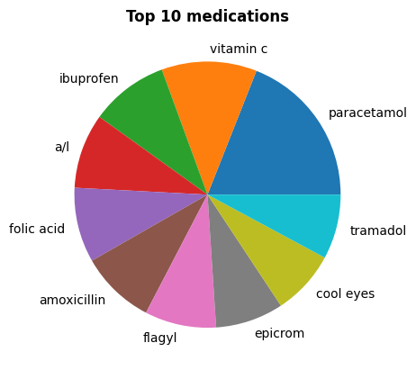

```python
top = medicines_percentage['percentage'][0:10]

plt.pie(top,labels=top.index )
plt.title('Top 10 medications',fontdict={'fontweight':'bold'})
plt.savefig('C:/Users/Daniel Appiah/Desktop/Overall Medications_pie.png')

plt.show()
```